# Final - Driver Coupon Acceptance

###### LABEL ENCODING

```python
df_cat.head(2)
```

|  | destination | passanger | weather | temperature | time | coupon | expiration | gender | age | maritalStatus | education | occupation | income | Bar | CoffeeHouse | CarryAway | RestaurantLessThan20 | Restaurant20To50 |
| --- | --- | --- | --- | --- | --- | --- | --- | --- | --- | --- | --- | --- | --- | --- | --- | --- | --- | --- |
| 0 | No Urgent Place | Alone | Sunny | 55 | 2PM | Restaurant(<20) | 1d | Female | 21 | Unmarried partner | Some college - no degree | Unemployed | $37500 - $49999 | never | never | 1~3 | 4~8 | 1~3 |
| 1 | No Urgent Place | Friend(s) | Sunny | 80 | 10AM | Coffee House | 2h | Female | 21 | Unmarried partner | Some college - no degree | Unemployed | $37500 - $49999 | never | never | 1~3 | 4~8 | 1~3 |

from sklearn.preprocessing import LabelEncoder le=LabelEncoder()

df_l_enc = pd.DataFrame()

```python
from sklearn.preprocessing import LabelEncoder

df_l_enc=pd.DataFrame()
z = df_cat.columns
cols = list(z)
df_l_enc[cols] = df_cat[cols].apply(LabelEncoder().fit_transform)
```

```python
df_l_enc.head(2)
```

|  | destination | passanger | weather | temperature | time | coupon | expiration | gender | age | maritalStatus | education | occupation | income | Bar | CoffeeHouse | CarryAway | RestaurantLessThan20 | Restaurant20To50 |
| --- | --- | --- | --- | --- | --- | --- | --- | --- | --- | --- | --- | --- | --- | --- | --- | --- | --- | --- |
| 0 | 1 | 0 | 2 | 1 | 2 | 4 | 0 | 0 | 0 | 3 | 5 | 24 | 3 | 4 | 4 | 0 | 1 | 0 |
| 1 | 1 | 1 | 2 | 2 | 0 | 2 | 1 | 0 | 0 | 3 | 5 | 24 | 3 | 4 | 4 | 0 | 1 | 0 |

```python
df_l_enc.columns
```

```
Index(['destination', 'passanger', 'weather', 'temperature', 'time', 'coupon',
       'expiration', 'gender', 'age', 'maritalStatus', 'education',
       'occupation', 'income', 'Bar', 'CoffeeHouse', 'CarryAway',
       'RestaurantLessThan20', 'Restaurant20To50'],
      dtype='object')
```

```python
for i in df_l_enc.columns:
    print(df[i])
    print('')
```

```
0        No Urgent Place
1        No Urgent Place
2        No Urgent Place
3        No Urgent Place
4        No Urgent Place
              ...
12679               Home
12680               Work
12681               Work
12682               Work
12683               Work
Name: destination, Length: 12684, dtype: object

0            Alone
1        Friend(s)
```

[output cut: 218 more lines]

###### FREQUENCY ENCODING

```python
df_f_enc=df_cat.copy()
```

```python
df_f_enc.head(2)
```

|  | destination | passanger | weather | temperature | time | coupon | expiration | gender | age | maritalStatus | education | occupation | income | Bar | CoffeeHouse | CarryAway | RestaurantLessThan20 | Restaurant20To50 |
| --- | --- | --- | --- | --- | --- | --- | --- | --- | --- | --- | --- | --- | --- | --- | --- | --- | --- | --- |
| 0 | No Urgent Place | Alone | Sunny | 55 | 2PM | Restaurant(<20) | 1d | Female | 21 | Unmarried partner | Some college - no degree | Unemployed | $37500 - $49999 | never | never | 1~3 | 4~8 | 1~3 |
| 1 | No Urgent Place | Friend(s) | Sunny | 80 | 10AM | Coffee House | 2h | Female | 21 | Unmarried partner | Some college - no degree | Unemployed | $37500 - $49999 | never | never | 1~3 | 4~8 | 1~3 |

```python
#frequency Encoding
for i in df_cat.columns:
    tab=df_f_enc[i].value_counts()
    df_f_enc[i]=df_f_enc[i].map(tab)
```

```python
df_f_enc.head()
```

|  | destination | passanger | weather | temperature | time | coupon | expiration | gender | age | maritalStatus | education | occupation | income | Bar | CoffeeHouse | CarryAway | RestaurantLessThan20 | Restaurant20To50 |
| --- | --- | --- | --- | --- | --- | --- | --- | --- | --- | --- | --- | --- | --- | --- | --- | --- | --- | --- |
| 0 | 6283 | 7305 | 10069 | 3840 | 2009 | 2786 | 7091 | 6511 | 2653 | 2186 | 4351 | 1870 | 1805 | 5304 | 2962 | 4823 | 3580 | 3290 |
| 1 | 6283 | 3298 | 10069 | 6528 | 2275 | 3996 | 5593 | 6511 | 2653 | 2186 | 4351 | 1870 | 1805 | 5304 | 2962 | 4823 | 3580 | 3290 |
| 2 | 6283 | 3298 | 10069 | 6528 | 2275 | 2393 | 5593 | 6511 | 2653 | 2186 | 4351 | 1870 | 1805 | 5304 | 2962 | 4823 | 3580 | 3290 |
| 3 | 6283 | 3298 | 10069 | 6528 | 2009 | 3996 | 5593 | 6511 | 2653 | 2186 | 4351 | 1870 | 1805 | 5304 | 2962 | 4823 | 3580 | 3290 |
| 4 | 6283 | 3298 | 10069 | 6528 | 2009 | 3996 | 7091 | 6511 | 2653 | 2186 | 4351 | 1870 | 1805 | 5304 | 2962 | 4823 | 3580 | 3290 |

```python
df_f_enc.columns
```

```
Index(['destination', 'passanger', 'weather', 'temperature', 'time', 'coupon',
       'expiration', 'gender', 'age', 'maritalStatus', 'education',
       'occupation', 'income', 'Bar', 'CoffeeHouse', 'CarryAway',
       'RestaurantLessThan20', 'Restaurant20To50'],
      dtype='object')
```

```python
for i in df_f_enc.columns:
    print(df[i].value_counts())
    print('')
```

```
No Urgent Place    6283
Home               3237
Work               3164
Name: destination, dtype: int64

Alone        7305
Friend(s)    3298
Partner      1075
Kid(s)       1006
Name: passanger, dtype: int64

Sunny    10069
Snowy     1405
Rainy     1210
Name: weather, dtype: int64

80    6528
55    3840
30    2316
Name: temperature, dtype: int64

6PM     3230
7AM     3164
10AM    2275
2PM     2009
10PM    2006
Name: time, dtype: int64

Coffee House             3996
Restaurant(<20)          2786
Carry out & Take away    2393
Bar                      2017
Restaurant(20-50)        1492
Name: coupon, dtype: int64

1d    7091
2h    5593
Name: expiration, dtype: int64

Female    6511
```

[output cut: 85 more lines]

```
Name: CarryAway, dtype: int64

1~3      5376
4~8      3580
less1    2093
gt8      1285
never     220
Name: RestaurantLessThan20, dtype: int64

less1    6077
1~3      3290
never    2136
4~8       728
gt8       264
Name: Restaurant20To50, dtype: int64
```

```python
#ENCODING IS DONE FOR CATEGORICAL DATA
```

###### MODEL BUILDING ON ONE HOT ENCODING

###### MERGING CATEGORICAL AND NUMERICAL DATA

```python
df_final = pd.concat([df_enc,df_num],axis=1)
```

```python
df_final.head()
```

|  | destination_No Urgent Place | destination_Work | passanger_Friend(s) | passanger_Kid(s) | passanger_Partner | weather_Snowy | weather_Sunny | temperature_55 | temperature_80 | time_10PM | ... | Restaurant20To50_4~8 | Restaurant20To50_gt8 | Restaurant20To50_less1 | Restaurant20To50_never | has_children | toCoupon_GEQ15min | toCoupon_GEQ25min | direction_same | direction_opp | Y |
| --- | --- | --- | --- | --- | --- | --- | --- | --- | --- | --- | --- | --- | --- | --- | --- | --- | --- | --- | --- | --- | --- |
| 0 | 1 | 0 | 0 | 0 | 0 | 0 | 1 | 1 | 0 | 0 | ... | 0 | 0 | 0 | 0 | 1 | 0 | 0 | 0 | 1 | 1 |
| 1 | 1 | 0 | 1 | 0 | 0 | 0 | 1 | 0 | 1 | 0 | ... | 0 | 0 | 0 | 0 | 1 | 0 | 0 | 0 | 1 | 0 |
| 2 | 1 | 0 | 1 | 0 | 0 | 0 | 1 | 0 | 1 | 0 | ... | 0 | 0 | 0 | 0 | 1 | 1 | 0 | 0 | 1 | 1 |
| 3 | 1 | 0 | 1 | 0 | 0 | 0 | 1 | 0 | 1 | 0 | ... | 0 | 0 | 0 | 0 | 1 | 1 | 0 | 0 | 1 | 0 |
| 4 | 1 | 0 | 1 | 0 | 0 | 0 | 1 | 0 | 1 | 0 | ... | 0 | 0 | 0 | 0 | 1 | 1 | 0 | 0 | 1 | 0 |

5 rows × 93 columns

```python
df_final.tail()
```

|  | destination_No Urgent Place | destination_Work | passanger_Friend(s) | passanger_Kid(s) | passanger_Partner | weather_Snowy | weather_Sunny | temperature_55 | temperature_80 | time_10PM | ... | Restaurant20To50_4~8 | Restaurant20To50_gt8 | Restaurant20To50_less1 | Restaurant20To50_never | has_children | toCoupon_GEQ15min | toCoupon_GEQ25min | direction_same | direction_opp | Y |
| --- | --- | --- | --- | --- | --- | --- | --- | --- | --- | --- | --- | --- | --- | --- | --- | --- | --- | --- | --- | --- | --- |
| 12679 | 0 | 0 | 0 | 0 | 1 | 0 | 0 | 1 | 0 | 0 | ... | 0 | 0 | 0 | 0 | 0 | 0 | 0 | 1 | 0 | 1 |
| 12680 | 0 | 1 | 0 | 0 | 0 | 0 | 0 | 1 | 0 | 0 | ... | 0 | 0 | 0 | 0 | 0 | 0 | 0 | 0 | 1 | 1 |
| 12681 | 0 | 1 | 0 | 0 | 0 | 1 | 0 | 0 | 0 | 0 | ... | 0 | 0 | 0 | 0 | 0 | 0 | 0 | 1 | 0 | 0 |
| 12682 | 0 | 1 | 0 | 0 | 0 | 1 | 0 | 0 | 0 | 0 | ... | 0 | 0 | 0 | 0 | 0 | 1 | 1 | 0 | 1 | 0 |
| 12683 | 0 | 1 | 0 | 0 | 0 | 0 | 1 | 0 | 1 | 0 | ... | 0 | 0 | 0 | 0 | 0 | 0 | 0 | 1 | 0 | 0 |

5 rows × 93 columns

```python
df_final.shape
```

```
(12684, 93)
```

```python
df_final.columns
```

```
Index(['destination_No Urgent Place', 'destination_Work',
       'passanger_Friend(s)', 'passanger_Kid(s)', 'passanger_Partner',
       'weather_Snowy', 'weather_Sunny', 'temperature_55', 'temperature_80',
       'time_10PM', 'time_2PM', 'time_6PM', 'time_7AM',
       'coupon_Carry out & Take away', 'coupon_Coffee House',
       'coupon_Restaurant(20-50)', 'coupon_Restaurant(<20)', 'expiration_2h',
       'gender_Male', 'age_26', 'age_31', 'age_36', 'age_41', 'age_46',
       'age_50plus', 'age_below21', 'maritalStatus_Married partner',
       'maritalStatus_Single', 'maritalStatus_Unmarried partner',
       'maritalStatus_Widowed', 'education_Bachelors degree',
       'education_Graduate degree (Masters or Doctorate)',
       'education_High School Graduate', 'education_Some High School',
       'education_Some college - no degree',
       'occupation_Arts Design Entertainment Sports & Media',
       'occupation_Building & Grounds Cleaning & Maintenance',
       'occupation_Business & Financial',
       'occupation_Community & Social Services',
       'occupation_Computer & Mathematical',
       'occupation_Construction & Extraction',
       'occupation_Education&Training&Library',
       'occupation_Farming Fishing & Forestry',
       'occupation_Food Preparation & Serving Related',
       'occupation_Healthcare Practitioners & Technical',
       'occupation_Healthcare Support',
       'occupation_Installation Maintenance & Repair', 'occupation_Legal',
       'occupation_Life Physical Social Science', 'occupation_Management',
       'occupation_Office & Administrative Support',
       'occupation_Personal Care & Service',
       'occupation_Production Occupations', 'occupation_Protective Service',
       'occupation_Retired', 'occupation_Sales & Related',
       'occupation_Student', 'occupation_Transportation & Material Moving',
       'occupation_Unemployed', 'income_$12500 - $24999',
       'income_$25000 - $37499', 'income_$37500 - $49999',
       'income_$50000 - $62499', 'income_$62500 - $74999',
       'income_$75000 - $87499', 'income_$87500 - $99999',
       'income_Less than $12500', 'Bar_4~8', 'Bar_gt8', 'Bar_less1',
       'Bar_never', 'CoffeeHouse_4~8', 'CoffeeHouse_gt8', 'CoffeeHouse_less1',
       'CoffeeHouse_never', 'CarryAway_4~8', 'CarryAway_gt8',
       'CarryAway_less1', 'CarryAway_never', 'RestaurantLessThan20_4~8',
       'RestaurantLessThan20_gt8', 'RestaurantLessThan20_less1',
       'RestaurantLessThan20_never', 'Restaurant20To50_4~8',
       'Restaurant20To50_gt8', 'Restaurant20To50_less1',
       'Restaurant20To50_never', 'has_children', 'toCoupon_GEQ15min',
       'toCoupon_GEQ25min', 'direction_same', 'direction_opp', 'Y'],
      dtype='object')
```

```python
X = df_final.drop('Y',axis=1)
y = df_final['Y']
```

###### TRAIN,TEST SPLIT

```python
# Splitting the dataset into the Training set and Test set
from sklearn.model_selection import train_test_split
X_train, X_test, y_train, y_test = train_test_split(X, y, test_size = 0.2, random_state = 1)
```

from sklearn.preprocessing import StandardScaler sc = StandardScaler() X_train = sc.fit_transform(X_train) X_test = sc.transform(X_test)

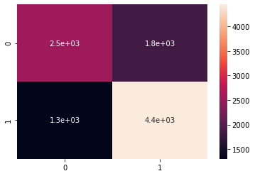

```
              precision    recall  f1-score   support

           0       0.66      0.58      0.62      4396
           1       0.71      0.77      0.74      5751

    accuracy                           0.69     10147
   macro avg       0.68      0.68      0.68     10147
weighted avg       0.69      0.69      0.69     10147

68.92677638710948
Percentage of correctly classified observations:  68.93
Percentage of misclassified observations:  31.07

Specificity:  0.5794
Sensitivity:  0.7733
Accuracy: 0.6892677638710949
Precision: 0.7063214739517154
Recall: 0.7732568249000173
```

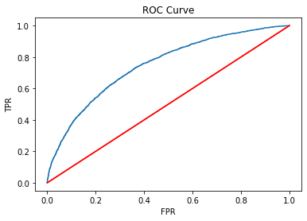

```
0.7470525757359284
```

```python
# Fitting Logistic Regression to the Training set
from sklearn.linear_model import LogisticRegression
classifier = LogisticRegression(random_state = 1)
classifier.fit(X_train, y_train)

# Predicting the Test set results
y_pred_train = classifier.predict(X_train)

# Making the Confusion Matrix
from sklearn.metrics import confusion_matrix, accuracy_score,roc_curve,roc_auc_score,precision_score,recall_score
cm = confusion_matrix(y_train, y_pred_train)

y_act = y_train
sns.heatmap(confusion_matrix(y_act,y_pred_train),annot=True)
plt.show()

from sklearn.metrics import classification_report
print(classification_report(y_train,y_pred_train))

lr_train_acc_score = accuracy_score(y_train, y_pred_train)
print(lr_train_acc_score*100)

cnf_mat = confusion_matrix(y_act,y_pred_train)
tn = cnf_mat[0,0]
tp = cnf_mat[1,1]
fp = cnf_mat[0,1]
fn = cnf_mat[1,0]
tn,tp,fp,fn

# True Negative from confusion matrix
TN = cm[0][0]
# True Positive from confusion matrix
TP = cm[1][1]
# False Positive from confusion matrix
FP = cm[0][1]
# False Negative from confusion matrix
FN = cm[1][0]

# add all the values of a confusion matrix
total = TN + TP + FP + FN

# find the percentage of correctly classified observations
# round the result upto 2 decimal points
correct_classified_percentage = ((TN+TP)/total)*100
print("Percentage of correctly classified observations: ", round(correct_classified_percentage, 2))

# find the percentage of  misclassified observations
# round the result upto 2 decimal points
misclassified_percentage = ((FP+FN)/total)*100
print("Percentage of misclassified observations: ", round(misclassified_percentage, 2))

# find the specificity
# round the result upto 4 decimal points
specificity = TN/(TN+FP)
print("\nSpecificity: ", round(specificity, 4))

# find the sensitivity
# round the result upto 4 decimal points
sensitivity = TP/(TP+FN)
print("Sensitivity: ", round(sensitivity, 4))


lr_train_acc = (tn+tp)/(tn+tp+fn+fp)
lr_train_acc

from sklearn import metrics
print("Accuracy:",metrics.accuracy_score(y_train, y_pred_train))
print("Precision:",metrics.precision_score(y_train, y_pred_train))
print("Recall:",metrics.recall_score(y_train, y_pred_train))

prob = classifier.predict_proba(X_train)
prob = prob[:,1]

fpr,tpr,thres = roc_curve(y_train,prob)
df_prob = pd.DataFrame({'TPR':tpr,'FPR':fpr,'Threshold':thres})
df_prob

plt.plot(fpr,tpr)
plt.plot([[0,0],[1,1]],color='red')

plt.xlabel('FPR')
plt.ylabel('TPR')
plt.title('ROC Curve')

plt.show()

roc_auc_score(y_train,prob)  # area under the curve
```

##### chi-square FEATURE SELECTION

```python
from sklearn.linear_model import LogisticRegression
from sklearn.feature_selection import RFE
#Recursive Feature Elimination
lr = LogisticRegression()
rfe = RFE(estimator=lr) # , scoring='r2')
rfe_model = rfe.fit(X,y)
rfe_model.ranking_
rank= pd.DataFrame()
rank['Feature']=X.columns
rank['Feature_Rank']=rfe_model.ranking_
fea_r=rank[rank['Feature_Rank']==1]
fea_r
```

|  | Feature | Feature_Rank |
| --- | --- | --- |
| 0 | destination_No Urgent Place | 1 |
| 2 | passanger_Friend(s) | 1 |
| 3 | passanger_Kid(s) | 1 |
| 4 | passanger_Partner | 1 |
| 6 | weather_Sunny | 1 |
| 7 | temperature_55 | 1 |
| 9 | time_10PM | 1 |
| 11 | time_6PM | 1 |
| 13 | coupon_Carry out & Take away | 1 |
| 14 | coupon_Coffee House | 1 |
| 15 | coupon_Restaurant(20-50) | 1 |
| 16 | coupon_Restaurant(<20) | 1 |
| 17 | expiration_2h | 1 |
| 18 | gender_Male | 1 |
| 21 | age_36 | 1 |
| 24 | age_50plus | 1 |
| 27 | maritalStatus_Single | 1 |
| 30 | education_Bachelors degree | 1 |
| 31 | education_Graduate degree (Masters or Doctorate) | 1 |
| 33 | education_Some High School | 1 |
| 35 | occupation_Arts Design Entertainment Sports & ... | 1 |
| 38 | occupation_Community & Social Services | 1 |
| 40 | occupation_Construction & Extraction | 1 |
| 42 | occupation_Farming Fishing & Forestry | 1 |
| 44 | occupation_Healthcare Practitioners & Technical | 1 |
| 45 | occupation_Healthcare Support | 1 |
| 46 | occupation_Installation Maintenance & Repair | 1 |
| 47 | occupation_Legal | 1 |
| 53 | occupation_Protective Service | 1 |
| 54 | occupation_Retired | 1 |
| 62 | income_$50000 - $62499 | 1 |
| 63 | income_$62500 - $74999 | 1 |
| 64 | income_$75000 - $87499 | 1 |
| 65 | income_$87500 - $99999 | 1 |
| 68 | Bar_gt8 | 1 |
| 69 | Bar_less1 | 1 |
| 70 | Bar_never | 1 |
| 72 | CoffeeHouse_gt8 | 1 |
| 73 | CoffeeHouse_less1 | 1 |
| 74 | CoffeeHouse_never | 1 |
| 80 | RestaurantLessThan20_gt8 | 1 |
| 85 | Restaurant20To50_less1 | 1 |
| 86 | Restaurant20To50_never | 1 |
| 89 | toCoupon_GEQ25min | 1 |
| 90 | direction_same | 1 |
| 91 | direction_opp | 1 |

```python
fea_r.count()
```

```
Feature         46
Feature_Rank    46
dtype: int64
```

```python
fea_r.keys()
```

```
Index(['Feature', 'Feature_Rank'], dtype='object')
```

```python
from sklearn import feature_selection
from sklearn.feature_selection import SelectKBest
from sklearn.feature_selection import chi2
```

```python
X_new= SelectKBest(chi2, k=46).fit_transform(X, y)
X_new.shape
```

```
(12684, 46)
```

X_new=X.astype(int)

chi2_selector=SelectKBest(chi2,k=55) chi2_selector.fit(X_new,y)

chi2_scores

###### TRAIN,TEST SPLIT

```python
# Splitting the dataset into the Training set and Test set
from sklearn.model_selection import train_test_split
X_train, X_test, y_train, y_test = train_test_split(X_new, y, test_size = 0.2, random_state = 1)
```

Feature scaling Next, we are doing feature scaling to the training and test set of independent variables

# Feature Scaling

from sklearn.preprocessing import StandardScaler sc = StandardScaler() X_train = sc.fit_transform(X_train) X_test = sc.transform(X_test)

###### LOGISTIC REGRESSION MODEL

###### LogisticRegression Model For Train Data

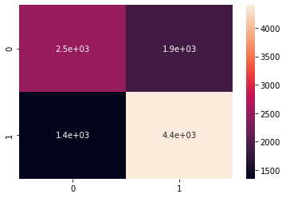

```
              precision    recall  f1-score   support

           0       0.65      0.57      0.61      4396
           1       0.70      0.77      0.73      5751

    accuracy                           0.68     10147
   macro avg       0.68      0.67      0.67     10147
weighted avg       0.68      0.68      0.68     10147

68.17778653789297
```

```python
# Fitting Logistic Regression to the Training set
from sklearn.linear_model import LogisticRegression
classifier = LogisticRegression(random_state = 0)
classifier.fit(X_train, y_train)

# Predicting the Test set results
y_pred_train = classifier.predict(X_train)

# Making the Confusion Matrix
from sklearn.metrics import confusion_matrix, accuracy_score,roc_curve,roc_auc_score,precision_score,recall_score
cm = confusion_matrix(y_train, y_pred_train)

y_act = y_train
sns.heatmap(confusion_matrix(y_act,y_pred_train),annot=True)
plt.show()

from sklearn.metrics import classification_report
print(classification_report(y_train,y_pred_train))

lr_train_acc_score = accuracy_score(y_train, y_pred_train)
print(lr_train_acc_score*100)
```

```python
cnf_mat = confusion_matrix(y_act,y_pred_train)
tn = cnf_mat[0,0]
tp = cnf_mat[1,1]
fp = cnf_mat[0,1]
fn = cnf_mat[1,0]
tn,tp,fp,fn
```

```
(2517, 4401, 1879, 1350)
```

```python
# True Negative from confusion matrix
TN = cm[0][0]
# True Positive from confusion matrix
TP = cm[1][1]
# False Positive from confusion matrix
FP = cm[0][1]
# False Negative from confusion matrix
FN = cm[1][0]

# add all the values of a confusion matrix
total = TN + TP + FP + FN

# find the percentage of correctly classified observations
# round the result upto 2 decimal points
correct_classified_percentage = ((TN+TP)/total)*100
print("Percentage of correctly classified observations: ", round(correct_classified_percentage, 2))

# find the percentage of  misclassified observations
# round the result upto 2 decimal points
misclassified_percentage = ((FP+FN)/total)*100
print("Percentage of misclassified observations: ", round(misclassified_percentage, 2))

# find the specificity
# round the result upto 4 decimal points
specificity = TN/(TN+FP)
print("\nSpecificity: ", round(specificity, 4))

# find the sensitivity
# round the result upto 4 decimal points
sensitivity = TP/(TP+FN)
print("Sensitivity: ", round(sensitivity, 4))
```

```
Percentage of correctly classified observations:  68.18
Percentage of misclassified observations:  31.82

Specificity:  0.5726
Sensitivity:  0.7653
```

```python
lr_train_acc = (tn+tp)/(tn+tp+fn+fp)
lr_train_acc
```

```
0.6817778653789297
```

```python
from sklearn import metrics
print("Accuracy:",metrics.accuracy_score(y_train, y_pred_train))
print("Precision:",metrics.precision_score(y_train, y_pred_train))
print("Recall:",metrics.recall_score(y_train, y_pred_train))
```

```
Accuracy: 0.6817778653789297
Precision: 0.700796178343949
Recall: 0.7652582159624414
```

ROC Curve Receiver Operating Characteristic(ROC) curve is a plot of the true positive rate against the false positive rate. It shows the tradeoff between sensitivity and specificity.

```python
prob = classifier.predict_proba(X_train)
prob = prob[:,1]
```

```python
fpr,tpr,thres = roc_curve(y_train,prob)
df_prob = pd.DataFrame({'TPR':tpr,'FPR':fpr,'Threshold':thres})
df_prob
```

|  | TPR | FPR | Threshold |
| --- | --- | --- | --- |
| 0 | 0.000000 | 0.000000 | 1.960060 |
| 1 | 0.000174 | 0.000000 | 0.960060 |
| 2 | 0.001913 | 0.000000 | 0.951186 |
| 3 | 0.001913 | 0.000227 | 0.950962 |
| 4 | 0.003825 | 0.000227 | 0.941608 |
| ... | ... | ... | ... |
| 4481 | 0.999478 | 0.997498 | 0.105642 |
| 4482 | 0.999478 | 0.997725 | 0.103048 |
| 4483 | 0.999652 | 0.997725 | 0.096612 |
| 4484 | 0.999652 | 1.000000 | 0.080389 |
| 4485 | 1.000000 | 1.000000 | 0.061691 |

4486 rows × 3 columns

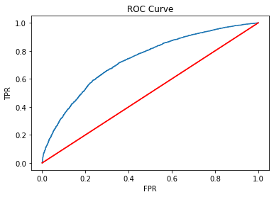

```python
plt.plot(fpr,tpr)
plt.plot([[0,0],[1,1]],color='red')

plt.xlabel('FPR')
plt.ylabel('TPR')
plt.title('ROC Curve')

plt.show()
```

```python
roc_auc_score(y_train,prob)  # area under the curve
```

```
0.7363589415711064
```

AUC score for the case is 0.74. AUC score 1 represents perfect classifier, and 0.5 represents a worthless classifier.

###### TEST DATA

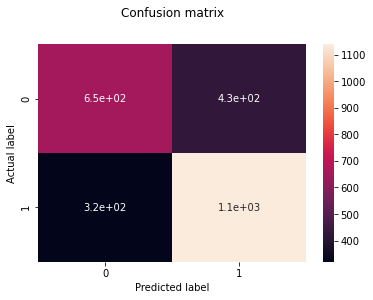

```
              precision    recall  f1-score   support

           0       0.67      0.60      0.63      1078
           1       0.73      0.78      0.75      1459

    accuracy                           0.71      2537
   macro avg       0.70      0.69      0.69      2537
weighted avg       0.70      0.71      0.70      2537

70.51635790303507
```

```python
# Fitting Logistic Regression to the Testing Data set
from sklearn.linear_model import LogisticRegression
classifier = LogisticRegression(random_state = 0)
classifier.fit(X_test, y_test)

# Predicting the Test set results
y_pred = classifier.predict(X_test)

# Making the Confusion Matrix
from sklearn.metrics import confusion_matrix, accuracy_score
cm = confusion_matrix(y_test, y_pred)

y_act = y_test
sns.heatmap(confusion_matrix(y_act,y_pred),annot=True)
plt.title('Confusion matrix', y=1.1)
plt.ylabel('Actual label')
plt.xlabel('Predicted label')
plt.show()

from sklearn.metrics import classification_report
print(classification_report(y_test,y_pred))

lr_test_acc_score = accuracy_score(y_test, y_pred)
print(lr_test_acc_score*100)
```

```python
cnf_mat = confusion_matrix(y_act,y_pred)
tn = cnf_mat[0,0]
tp = cnf_mat[1,1]
fp = cnf_mat[0,1]
fn = cnf_mat[1,0]
tn,tp,fp,fn
```

```
(650, 1139, 428, 320)
```

```python
# True Negative from confusion matrix
TN = cm[0][0]
# True Positive from confusion matrix
TP = cm[1][1]
# False Positive from confusion matrix
FP = cm[0][1]
# False Negative from confusion matrix
FN = cm[1][0]

# add all the values of a confusion matrix
total = TN + TP + FP + FN

# find the percentage of correctly classified observations
# round the result upto 2 decimal points
correct_classified_percentage = ((TN+TP)/total)*100
print("Percentage of correctly classified observations: ", round(correct_classified_percentage, 2))

# find the percentage of  misclassified observations
# round the result upto 2 decimal points
misclassified_percentage = ((FP+FN)/total)*100
print("Percentage of misclassified observations: ", round(misclassified_percentage, 2))

# find the specificity
# round the result upto 4 decimal points
specificity = TN/(TN+FP)
print("\nSpecificity: ", round(specificity, 4))

# find the sensitivity
# round the result upto 4 decimal points
sensitivity = TP/(TP+FN)
print("Sensitivity: ", round(sensitivity, 4))
```

```
Percentage of correctly classified observations:  70.52
Percentage of misclassified observations:  29.48

Specificity:  0.603
Sensitivity:  0.7807
```

```python
lr_test_acc = (tn+tp)/(tn+tp+fn+fp)
lr_test_acc
```

```
0.7051635790303508
```

```python
prob = classifier.predict_proba(X_test)
prob = prob[:,1]
```

```python
fpr,tpr,thres = roc_curve(y_test,prob)
df_prob = pd.DataFrame({'TPR':tpr,'FPR':fpr,'Threshold':thres})
df_prob
```

|  | TPR | FPR | Threshold |
| --- | --- | --- | --- |
| 0 | 0.000000 | 0.000000 | 1.965114 |
| 1 | 0.000685 | 0.000000 | 0.965114 |
| 2 | 0.003427 | 0.000000 | 0.945932 |
| 3 | 0.003427 | 0.000928 | 0.943703 |
| 4 | 0.004112 | 0.000928 | 0.943575 |
| ... | ... | ... | ... |
| 1023 | 0.998629 | 0.996289 | 0.107062 |
| 1024 | 0.999315 | 0.996289 | 0.100311 |
| 1025 | 0.999315 | 0.998145 | 0.083976 |
| 1026 | 1.000000 | 0.998145 | 0.083074 |
| 1027 | 1.000000 | 1.000000 | 0.077748 |

1028 rows × 3 columns

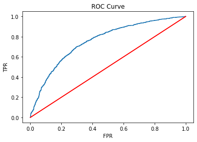

```python
plt.plot(fpr,tpr)
plt.plot([[0,0],[1,1]],color='red')
plt.xlabel('FPR')
plt.ylabel('TPR')
plt.title('ROC Curve')
plt.show()
```

```python
roc_auc_score(y_test,prob)  # area under the curve
```

```
0.7554927447955941
```

##### Naive Bayes

```python
from sklearn.naive_bayes import GaussianNB
```

###### Train Data

```python
# instantiate the 'GaussianNB'
gnb = GaussianNB()

# fit the model using fit() on train data
gnb_model_train = gnb.fit(X_train, y_train)

# predict the attrition for test set
y_pred_train = gnb_model_train.predict(X_train)

# print the classification report
print(classification_report(y_train, y_pred_train))
```

```
              precision    recall  f1-score   support

           0       0.56      0.68      0.62      4396
           1       0.71      0.60      0.65      5751

    accuracy                           0.63     10147
   macro avg       0.64      0.64      0.63     10147
weighted avg       0.65      0.63      0.63     10147
```

Interpretation: The recall for the positive class (i.e. customers who used the coupon) and the recall of the negative class (i.e. customers who will not use coupon) are stable. Thus, we can say that our model is performing good.

Note: Recall for the positive class is also known as Sensitivity and Recall for the negative class is also known as Specificity.

```python
# define a function to plot the ROC curve and print the ROC-AUC score
def plot_roc(model):

    # predict the probability of target variable using X_train
    # consider the probability of positive class by subsetting with '[:,1]'
    y_pred_prob_train = model.predict_proba(X_train)[:,1]

    # the roc_curve() returns the values for false positive rate, true positive rate and threshold
    # pass the actual target values and predicted probabilities to the function
    fpr, tpr, thresholds = roc_curve(y_train, y_pred_prob_train)

    # plot the ROC curve
    plt.plot(fpr, tpr)

    # set limits for x and y axes
    plt.xlim([0.0, 1.0])
    plt.ylim([0.0, 1.0])

    # plot the straight line showing worst prediction for the model
    plt.plot([0, 1], [0, 1],'r--')

    # add plot and axes labels
    # set text size using 'fontsize'
    plt.title('ROC curve for Driver Coupon Acceptance Prediction', fontsize = 15)
    plt.xlabel('False positive rate (1-Specificity)', fontsize = 15)
    plt.ylabel('True positive rate (Sensitivity)', fontsize = 15)

    # add the AUC score to the plot
    # 'x' and 'y' gives position of the text
    # 's' is the text
    # use round() to round-off the AUC score upto 4 digits
    plt.text(x = 0.02, y = 0.9, s = ('AUC Score:',round(roc_auc_score(y_train, y_pred_prob_train),4)))

    # plot the grid
    plt.grid(True)
```

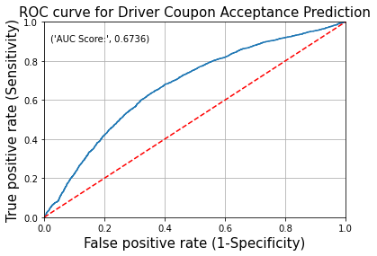

```python
# plot the ROC curve
plot_roc(gnb_model_train)
```

```python
roc_auc_score(y_train, y_pred_train)
```

```
0.6386851026739188
```

```python
# define a to plot a confusion matrix for the model
from matplotlib.colors import ListedColormap
def plot_confusion_matrix(model):

    # predict the target values using X_train
    y_pred_train = model.predict(X_train)

    # create a confusion matrix
    # pass the actual and predicted target values to the confusion_matrix()
    cm = confusion_matrix(y_train, y_pred_train)

    # label the confusion matrix
    # pass the matrix as 'data'
    # pass the required column names to the parameter, 'columns'
    # pass the required row names to the parameter, 'index'
    conf_matrix = pd.DataFrame(data = cm,columns = ['Predicted:0','Predicted:1'],
                               index = ['Actual:0','Actual:1'])

    # plot a heatmap to visualize the confusion matrix
    # 'annot' prints the value of each grid
    # 'fmt = d' returns the integer value in each grid
    # 'cmap' assigns color to each grid
    # as we do not require different colors for each grid in the heatmap,
    # use 'ListedColormap' to assign the specified color to the grid
    # 'cbar = False' will not return the color bar to the right side of the heatmap
    # 'linewidths' assigns the width to the line that divides each grid
    # 'annot_kws = {'size':25})' assigns the font size of the annotated text
    sns.heatmap(conf_matrix, annot = True, fmt = 'd', cbar = False,cmap = ListedColormap(['lightskyblue']),
                linewidths = 0.1, annot_kws = {'size':15})

    # set the font size of x-axis ticks using 'fontsize'
    plt.xticks(fontsize = 10)

    # set the font size of y-axis ticks using 'fontsize'
    plt.yticks(fontsize = 10)

    # display the plot
    plt.show()#### Define a function to plot the confusion matrix.
```

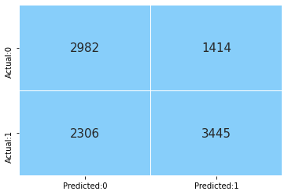

```python
# call the function to plot the confusion matrix
# pass the knn model to the function
plot_confusion_matrix(gnb_model_train)
```

```python
cnf_mat = confusion_matrix(y_train,y_pred_train)
tn = cnf_mat[0,0]
tp = cnf_mat[1,1]
fp = cnf_mat[0,1]
fn = cnf_mat[1,0]
tn,tp,fp,fn
```

```
(2982, 3445, 1414, 2306)
```

```python
# True Negative from confusion matrix
TN = cm[0][0]
# True Positive from confusion matrix
TP = cm[1][1]
# False Positive from confusion matrix
FP = cm[0][1]
# False Negative from confusion matrix
FN = cm[1][0]

# add all the values of a confusion matrix
total = TN + TP + FP + FN

# find the percentage of correctly classified observations
# round the result upto 2 decimal points
correct_classified_percentage = ((TN+TP)/total)*100
print("Percentage of correctly classified observations: ", round(correct_classified_percentage, 2))

# find the percentage of  misclassified observations
# round the result upto 2 decimal points
misclassified_percentage = ((FP+FN)/total)*100
print("Percentage of misclassified observations: ", round(misclassified_percentage, 2))

# find the specificity
# round the result upto 4 decimal points
specificity = TN/(TN+FP)
print("\nSpecificity: ", round(specificity, 4))

# find the sensitivity
# round the result upto 4 decimal points
sensitivity = TP/(TP+FN)
print("Sensitivity: ", round(sensitivity, 4))
```

```
Percentage of correctly classified observations:  70.52
Percentage of misclassified observations:  29.48

Specificity:  0.603
Sensitivity:  0.7807
```

```python
nb_train_acc = (tn+tp)/(tn+tp+fn+fp)
nb_train_acc
```

```
0.6333891790677048
```

```python
print("Accuracy:",metrics.accuracy_score(y_train, y_pred_train))
print("Precision:",metrics.precision_score(y_train, y_pred_train))
print("Recall:",metrics.recall_score(y_train, y_pred_train))
```

```
Accuracy: 0.6333891790677048
Precision: 0.7089936200864375
Recall: 0.5990262563032516
```

###### TEST DATASET

```python
# instantiate the 'GaussianNB'
gnb = GaussianNB()

# fit the model using fit() on TEST data
gnb_model_test = gnb.fit(X_test, y_test)

# predict the attrition for test set
y_pred = gnb_model_test.predict(X_test)

# print the classification report
print(classification_report(y_test, y_pred))
```

```
              precision    recall  f1-score   support

           0       0.56      0.68      0.62      1078
           1       0.72      0.61      0.66      1459

    accuracy                           0.64      2537
   macro avg       0.64      0.65      0.64      2537
weighted avg       0.65      0.64      0.64      2537
```

Interpretation: The recall for the positive class (i.e. customers who used the coupon) and the recall of the negative class (i.e. customers who will not use coupon) are stable. Thus, we can say that our model is performing good.

Note: Recall for the positive class is also known as Sensitivity and Recall for the negative class is also known as Specificity.

```python
# define a function to plot the ROC curve and print the ROC-AUC score
def plot_roc(model):

    # predict the probability of target variable using X_test
    # consider the probability of positive class by subsetting with '[:,1]'
    y_pred_prob_test = model.predict_proba(X_test)[:,1]

    # the roc_curve() returns the values for false positive rate, true positive rate and threshold
    # pass the actual target values and predicted probabilities to the function
    fpr, tpr, thresholds = roc_curve(y_test, y_pred_prob_test)

    # plot the ROC curve
    plt.plot(fpr, tpr)

    # set limits for x and y axes
    plt.xlim([0.0, 1.0])
    plt.ylim([0.0, 1.0])

    # plot the straight line showing worst prediction for the model
    plt.plot([0, 1], [0, 1],'r--')

    # add plot and axes labels
    # set text size using 'fontsize'
    plt.title('ROC curve for Driver Coupon Acceptance Prediction', fontsize = 15)
    plt.xlabel('False positive rate (1-Specificity)', fontsize = 15)
    plt.ylabel('True positive rate (Sensitivity)', fontsize = 15)

    # add the AUC score to the plot
    # 'x' and 'y' gives position of the text
    # 's' is the text
    # use round() to round-off the AUC score upto 4 digits
    plt.text(x = 0.02, y = 0.9, s = ('AUC Score:',round(roc_auc_score(y_test, y_pred_prob_test),4)))

    # plot the grid
    plt.grid(True)
```

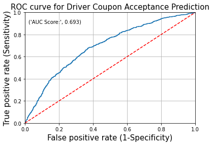

```python
# plot the ROC curve
plot_roc(gnb_model_test)
```

```python
roc_auc_score(y_test,prob)  # area under the curve
```

```
0.7554927447955941
```

```python
# define a to plot a confusion matrix for the model
from matplotlib.colors import ListedColormap
def plot_confusion_matrix(model):

    # predict the target values using X_test
    y_pred_test = model.predict(X_test)

    # create a confusion matrix
    # pass the actual and predicted target values to the confusion_matrix()
    cm = confusion_matrix(y_test, y_pred_test)

    # label the confusion matrix
    # pass the matrix as 'data'
    # pass the required column names to the parameter, 'columns'
    # pass the required row names to the parameter, 'index'
    conf_matrix = pd.DataFrame(data = cm,columns = ['Predicted:0','Predicted:1'],
                               index = ['Actual:0','Actual:1'])

    # plot a heatmap to visualize the confusion matrix
    # 'annot' prints the value of each grid
    # 'fmt = d' returns the integer value in each grid
    # 'cmap' assigns color to each grid
    # as we do not require different colors for each grid in the heatmap,
    # use 'ListedColormap' to assign the specified color to the grid
    # 'cbar = False' will not return the color bar to the right side of the heatmap
    # 'linewidths' assigns the width to the line that divides each grid
    # 'annot_kws = {'size':25})' assigns the font size of the annotated text
    sns.heatmap(conf_matrix, annot = True, fmt = 'd', cbar = False,cmap = ListedColormap(['lightskyblue']),
                linewidths = 0.1, annot_kws = {'size':15})

    # set the font size of x-axis ticks using 'fontsize'
    plt.xticks(fontsize = 10)

    # set the font size of y-axis ticks using 'fontsize'
    plt.yticks(fontsize = 10)

    # display the plot
    plt.show()#### Define a function to plot the confusion matrix.
```

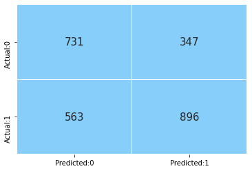

```python
# call the function to plot the confusion matrix
# pass the naive model to the function
plot_confusion_matrix(gnb_model_test)
```

```python
cnf_mat = confusion_matrix(y_act,y_pred)
tn = cnf_mat[0,0]
tp = cnf_mat[1,1]
fp = cnf_mat[0,1]
fn = cnf_mat[1,0]
tn,tp,fp,fn
```

```
(731, 896, 347, 563)
```

```python
# True Negative from confusion matrix
TN = cm[0][0]
# True Positive from confusion matrix
TP = cm[1][1]
# False Positive from confusion matrix
FP = cm[0][1]
# False Negative from confusion matrix
FN = cm[1][0]

# add all the values of a confusion matrix
total = TN + TP + FP + FN

# find the percentage of correctly classified observations
# round the result upto 2 decimal points
correct_classified_percentage = ((TN+TP)/total)*100
print("Percentage of correctly classified observations: ", round(correct_classified_percentage, 2))

# find the percentage of  misclassified observations
# round the result upto 2 decimal points
misclassified_percentage = ((FP+FN)/total)*100
print("Percentage of misclassified observations: ", round(misclassified_percentage, 2))

# find the specificity
# round the result upto 4 decimal points
specificity = TN/(TN+FP)
print("\nSpecificity: ", round(specificity, 4))

# find the sensitivity
# round the result upto 4 decimal points
sensitivity = TP/(TP+FN)
print("Sensitivity: ", round(sensitivity, 4))
```

```
Percentage of correctly classified observations:  70.52
Percentage of misclassified observations:  29.48

Specificity:  0.603
Sensitivity:  0.7807
```

```python
nb_test_acc = (tn+tp)/(tn+tp+fn+fp)
nb_test_acc
```

```
0.6413086322428064
```

```python
print("Accuracy:",metrics.accuracy_score(y_test, y_pred))
print("Precision:",metrics.precision_score(y_test, y_pred))
print("Recall:",metrics.recall_score(y_test, y_pred))
```

```
Accuracy: 0.6413086322428064
Precision: 0.7208366854384554
Recall: 0.6141192597669637
```

##### DECISION TREE

```python
from sklearn.tree import DecisionTreeClassifier
from sklearn import tree
```

```python
# fit the model using fit() on train data
decision_tree = DecisionTreeClassifier(random_state=1)
decision_tree = decision_tree.fit(X_train, y_train)
```

```python
#calculate training accuracy
y_pred_train = decision_tree.predict(X_train)

# pass the actual and predicted target values to the accuracy_score()
print("Train_Accuracy:",accuracy_score(y_train, y_pred_train))
```

```
Train_Accuracy: 0.9840346900561743
```

```python
pre_train = decision_tree.predict(X_train)
print(classification_report(y_train,pre_train))
```

```
              precision    recall  f1-score   support

           0       0.97      1.00      0.98      4396
           1       1.00      0.97      0.99      5751

    accuracy                           0.98     10147
   macro avg       0.98      0.99      0.98     10147
weighted avg       0.98      0.98      0.98     10147
```

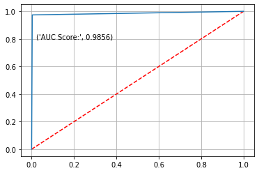

```python
# the roc_curve() returns the values for false positive rate, true positive rate and threshold
# pass the actual target values and predicted probabilities to the function
fpr, tpr, thresholds = roc_curve(y_train, y_pred_train)

# plot the straight line showing worst prediction for the model
plt.plot([0, 1], [0, 1],'r--')

# plot the ROC curve
plt.plot(fpr, tpr)

# add the AUC score to the plot
# 'x' and 'y' gives position of the text
# 's' is the text
# use round() to round-off the AUC score upto 4 digits
plt.text(x = 0.02, y = 0.8, s = ('AUC Score:',round(metrics.roc_auc_score(y_train, y_pred_train),4)))

# plot the grid
plt.grid(True)
```

```python
roc_auc_score(y_train,y_pred_train)
```

```
0.9855671142527097
```

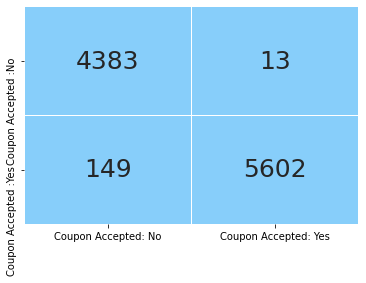

```python
# create a confusion matrix
# pass the actual and predicted target values to the confusion_matrix()
cm = confusion_matrix(y_train, y_pred_train)

# label the confusion matrix
# pass the matrix as 'data'
# pass the required column names to the parameter, 'columns'
# pass the required row names to the parameter, 'index'
conf_matrix = pd.DataFrame(data = cm,columns = ['Coupon Accepted: No','Coupon Accepted: Yes'],
                           index = ['Coupon Accepted :No','Coupon Accepted :Yes'])

# plot a heatmap to visualize the confusion matrix
# 'annot' prints the value of each grid
# 'fmt = d' returns the integer value in each grid
# 'cmap' assigns color to each grid
# as we do not require different colors for each grid in the heatmap,
# use 'ListedColormap' to assign the specified color to the grid
# 'cbar = False' will not return the color bar to the right side of the heatmap
# 'linewidths' assigns the width to the line that divides each grid
# 'annot_kws = {'size':25})' assigns the font size of the annotated text
sns.heatmap(conf_matrix, annot = True, fmt = 'd', cmap = ListedColormap(['lightskyblue']), cbar = False,
            linewidths = 0.1, annot_kws = {'size':25})

# set the font size of x-axis ticks using 'fontsize'
plt.xticks(fontsize = 10)

# set the font size of y-axis ticks using 'fontsize'
plt.yticks(fontsize = 10)

# display the plot
plt.show()
```

```python
# True Negative from confusion matrix
TN = cm[0][0]
# True Positive from confusion matrix
TP = cm[1][1]
# False Positive from confusion matrix
FP = cm[0][1]
# False Negative from confusion matrix
FN = cm[1][0]

# add all the values of a confusion matrix
total = TN + TP + FP + FN

# find the percentage of correctly classified observations
# round the result upto 2 decimal points
correct_classified_percentage = ((TN+TP)/total)*100
print("Percentage of correctly classified observations: ", round(correct_classified_percentage, 2))

# find the percentage of  misclassified observations
# round the result upto 2 decimal points
misclassified_percentage = ((FP+FN)/total)*100
print("Percentage of misclassified observations: ", round(misclassified_percentage, 2))

# find the specificity
# round the result upto 4 decimal points
specificity = TN/(TN+FP)
print("\nSpecificity: ", round(specificity, 4))

# find the sensitivity
# round the result upto 4 decimal points
sensitivity = TP/(TP+FN)
print("Sensitivity: ", round(sensitivity, 4))
```

```
Percentage of correctly classified observations:  98.4
Percentage of misclassified observations:  1.6

Specificity:  0.997
Sensitivity:  0.9741
```

# Decision Tree for Test data

```python
# prediction for test set
y_pred_test = decision_tree.predict(X_test)

# pass the actual and predicted target values to the accuracy_score()
print("Test_Accuracy:",accuracy_score(y_test, y_pred))
```

```
Test_Accuracy: 0.6413086322428064
```

```python
pre_test = decision_tree.predict(X_test)
print(classification_report(y_test,pre_test))
```

```
              precision    recall  f1-score   support

           0       0.62      0.63      0.63      1078
           1       0.73      0.71      0.72      1459

    accuracy                           0.68      2537
   macro avg       0.67      0.67      0.67      2537
weighted avg       0.68      0.68      0.68      2537
```

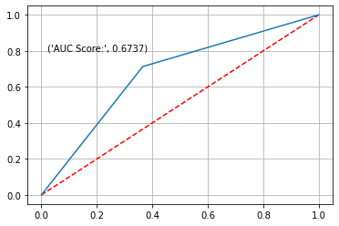

```python
# the roc_curve() returns the values for false positive rate, true positive rate and threshold
# pass the actual target values and predicted probabilities to the function
fpr, tpr, thresholds = roc_curve(y_test, y_pred_test)

# plot the straight line showing worst prediction for the model
plt.plot([0, 1], [0, 1],'r--')

# plot the ROC curve
plt.plot(fpr, tpr)

# add the AUC score to the plot
# 'x' and 'y' gives position of the text
# 's' is the text
# use round() to round-off the AUC score upto 4 digits
plt.text(x = 0.02, y = 0.8, s = ('AUC Score:',round(metrics.roc_auc_score(y_test, y_pred_test),4)))

# plot the grid
plt.grid(True)
```

```python
roc_auc_score(y_test,pre_test)
```

```
0.67366267336893
```

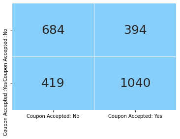

```python
# create a confusion matrix
# pass the actual and predicted target values to the confusion_matrix()
cm = confusion_matrix(y_test, y_pred_test)

# label the confusion matrix
# pass the matrix as 'data'
# pass the required column names to the parameter, 'columns'
# pass the required row names to the parameter, 'index'
conf_matrix = pd.DataFrame(data = cm,columns = ['Coupon Accepted: No','Coupon Accepted: Yes'],
                           index = ['Coupon Accepted :No','Coupon Accepted :Yes'])

# plot a heatmap to visualize the confusion matrix
# 'annot' prints the value of each grid
# 'fmt = d' returns the integer value in each grid
# 'cmap' assigns color to each grid
# as we do not require different colors for each grid in the heatmap,
# use 'ListedColormap' to assign the specified color to the grid
# 'cbar = False' will not return the color bar to the right side of the heatmap
# 'linewidths' assigns the width to the line that divides each grid
# 'annot_kws = {'size':25})' assigns the font size of the annotated text
sns.heatmap(conf_matrix, annot = True, fmt = 'd', cmap = ListedColormap(['lightskyblue']), cbar = False,
            linewidths = 0.1, annot_kws = {'size':25})

# set the font size of x-axis ticks using 'fontsize'
plt.xticks(fontsize = 10)

# set the font size of y-axis ticks using 'fontsize'
plt.yticks(fontsize = 10)

# display the plot
plt.show()
```

```python
# True Negative from confusion matrix
TN = cm[0][0]
# True Positive from confusion matrix
TP = cm[1][1]
# False Positive from confusion matrix
FP = cm[0][1]
# False Negative from confusion matrix
FN = cm[1][0]

# add all the values of a confusion matrix
total = TN + TP + FP + FN

# find the percentage of correctly classified observations
# round the result upto 2 decimal points
correct_classified_percentage = ((TN+TP)/total)*100
print("Percentage of correctly classified observations: ", round(correct_classified_percentage, 2))

# find the percentage of  misclassified observations
# round the result upto 2 decimal points
misclassified_percentage = ((FP+FN)/total)*100
print("Percentage of misclassified observations: ", round(misclassified_percentage, 2))

# find the specificity
# round the result upto 4 decimal points
specificity = TN/(TN+FP)
print("\nSpecificity: ", round(specificity, 4))

# find the sensitivity
# round the result upto 4 decimal points
sensitivity = TP/(TP+FN)
print("Sensitivity: ", round(sensitivity, 4))
```

```
Percentage of correctly classified observations:  67.95
Percentage of misclassified observations:  32.05

Specificity:  0.6345
Sensitivity:  0.7128
```

###### MODEL BUILDING ON LABEL ENCODING

```python
#MODEL BUILDING ON LABEL ENCODING
#MERGING CATEGORICAL AND NUMERICAL DATA

df_final_l = pd.concat([df_l_enc,df_num],axis=1)
df_final_l
```

|  | destination | passanger | weather | temperature | time | coupon | expiration | gender | age | maritalStatus | ... | CoffeeHouse | CarryAway | RestaurantLessThan20 | Restaurant20To50 | has_children | toCoupon_GEQ15min | toCoupon_GEQ25min | direction_same | direction_opp | Y |
| --- | --- | --- | --- | --- | --- | --- | --- | --- | --- | --- | --- | --- | --- | --- | --- | --- | --- | --- | --- | --- | --- |
| 0 | 1 | 0 | 2 | 1 | 2 | 4 | 0 | 0 | 0 | 3 | ... | 4 | 0 | 1 | 0 | 1 | 0 | 0 | 0 | 1 | 1 |
| 1 | 1 | 1 | 2 | 2 | 0 | 2 | 1 | 0 | 0 | 3 | ... | 4 | 0 | 1 | 0 | 1 | 0 | 0 | 0 | 1 | 0 |
| 2 | 1 | 1 | 2 | 2 | 0 | 1 | 1 | 0 | 0 | 3 | ... | 4 | 0 | 1 | 0 | 1 | 1 | 0 | 0 | 1 | 1 |
| 3 | 1 | 1 | 2 | 2 | 2 | 2 | 1 | 0 | 0 | 3 | ... | 4 | 0 | 1 | 0 | 1 | 1 | 0 | 0 | 1 | 0 |
| 4 | 1 | 1 | 2 | 2 | 2 | 2 | 0 | 0 | 0 | 3 | ... | 4 | 0 | 1 | 0 | 1 | 1 | 0 | 0 | 1 | 0 |
| ... | ... | ... | ... | ... | ... | ... | ... | ... | ... | ... | ... | ... | ... | ... | ... | ... | ... | ... | ... | ... | ... |
| 12679 | 0 | 3 | 0 | 1 | 3 | 1 | 0 | 1 | 1 | 2 | ... | 4 | 0 | 1 | 0 | 0 | 0 | 0 | 1 | 0 | 1 |
| 12680 | 2 | 0 | 0 | 1 | 4 | 1 | 0 | 1 | 1 | 2 | ... | 4 | 0 | 1 | 0 | 0 | 0 | 0 | 0 | 1 | 1 |
| 12681 | 2 | 0 | 1 | 0 | 4 | 2 | 0 | 1 | 1 | 2 | ... | 4 | 0 | 1 | 0 | 0 | 0 | 0 | 1 | 0 | 0 |
| 12682 | 2 | 0 | 1 | 0 | 4 | 0 | 0 | 1 | 1 | 2 | ... | 4 | 0 | 1 | 0 | 0 | 1 | 1 | 0 | 1 | 0 |
| 12683 | 2 | 0 | 2 | 2 | 4 | 3 | 1 | 1 | 1 | 2 | ... | 4 | 0 | 1 | 0 | 0 | 0 | 0 | 1 | 0 | 0 |

12684 rows × 24 columns

```python
df_final_l.head()
```

|  | destination | passanger | weather | temperature | time | coupon | expiration | gender | age | maritalStatus | ... | CoffeeHouse | CarryAway | RestaurantLessThan20 | Restaurant20To50 | has_children | toCoupon_GEQ15min | toCoupon_GEQ25min | direction_same | direction_opp | Y |
| --- | --- | --- | --- | --- | --- | --- | --- | --- | --- | --- | --- | --- | --- | --- | --- | --- | --- | --- | --- | --- | --- |
| 0 | 1 | 0 | 2 | 1 | 2 | 4 | 0 | 0 | 0 | 3 | ... | 4 | 0 | 1 | 0 | 1 | 0 | 0 | 0 | 1 | 1 |
| 1 | 1 | 1 | 2 | 2 | 0 | 2 | 1 | 0 | 0 | 3 | ... | 4 | 0 | 1 | 0 | 1 | 0 | 0 | 0 | 1 | 0 |
| 2 | 1 | 1 | 2 | 2 | 0 | 1 | 1 | 0 | 0 | 3 | ... | 4 | 0 | 1 | 0 | 1 | 1 | 0 | 0 | 1 | 1 |
| 3 | 1 | 1 | 2 | 2 | 2 | 2 | 1 | 0 | 0 | 3 | ... | 4 | 0 | 1 | 0 | 1 | 1 | 0 | 0 | 1 | 0 |
| 4 | 1 | 1 | 2 | 2 | 2 | 2 | 0 | 0 | 0 | 3 | ... | 4 | 0 | 1 | 0 | 1 | 1 | 0 | 0 | 1 | 0 |

5 rows × 24 columns

```python
df_final_l.tail()
```

|  | destination | passanger | weather | temperature | time | coupon | expiration | gender | age | maritalStatus | ... | CoffeeHouse | CarryAway | RestaurantLessThan20 | Restaurant20To50 | has_children | toCoupon_GEQ15min | toCoupon_GEQ25min | direction_same | direction_opp | Y |
| --- | --- | --- | --- | --- | --- | --- | --- | --- | --- | --- | --- | --- | --- | --- | --- | --- | --- | --- | --- | --- | --- |
| 12679 | 0 | 3 | 0 | 1 | 3 | 1 | 0 | 1 | 1 | 2 | ... | 4 | 0 | 1 | 0 | 0 | 0 | 0 | 1 | 0 | 1 |
| 12680 | 2 | 0 | 0 | 1 | 4 | 1 | 0 | 1 | 1 | 2 | ... | 4 | 0 | 1 | 0 | 0 | 0 | 0 | 0 | 1 | 1 |
| 12681 | 2 | 0 | 1 | 0 | 4 | 2 | 0 | 1 | 1 | 2 | ... | 4 | 0 | 1 | 0 | 0 | 0 | 0 | 1 | 0 | 0 |
| 12682 | 2 | 0 | 1 | 0 | 4 | 0 | 0 | 1 | 1 | 2 | ... | 4 | 0 | 1 | 0 | 0 | 1 | 1 | 0 | 1 | 0 |
| 12683 | 2 | 0 | 2 | 2 | 4 | 3 | 1 | 1 | 1 | 2 | ... | 4 | 0 | 1 | 0 | 0 | 0 | 0 | 1 | 0 | 0 |

5 rows × 24 columns

```python
df_final_l.shape
```

```
(12684, 24)
```

```python
df_final_l.columns
```

```
Index(['destination', 'passanger', 'weather', 'temperature', 'time', 'coupon',
       'expiration', 'gender', 'age', 'maritalStatus', 'education',
       'occupation', 'income', 'Bar', 'CoffeeHouse', 'CarryAway',
       'RestaurantLessThan20', 'Restaurant20To50', 'has_children',
       'toCoupon_GEQ15min', 'toCoupon_GEQ25min', 'direction_same',
       'direction_opp', 'Y'],
      dtype='object')
```

```python
#Our Data is Now Ready For Model Building
#Split the variables
X = df_final_l.drop('Y',axis=1)
y = df_final_l['Y']
```

```python
# Splitting the dataset into the Training set and Test set
from sklearn.model_selection import train_test_split
X_train, X_test, y_train, y_test = train_test_split(X, y, test_size = 0.2, random_state = 1)
```

# Feature Scaling

from sklearn.preprocessing import StandardScaler sc = StandardScaler() X_train = sc.fit_transform(X_train) X_test = sc.transform(X_test)

###### LOGISTIC REGRESSION MODEL

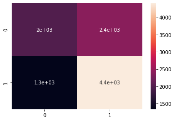

```
              precision    recall  f1-score   support

           0       0.60      0.45      0.52      4396
           1       0.65      0.77      0.70      5751

    accuracy                           0.63     10147
   macro avg       0.62      0.61      0.61     10147
weighted avg       0.63      0.63      0.62     10147

63.09253966689662
```

```python
# Fitting Logistic Regression to the Training set
from sklearn.linear_model import LogisticRegression
classifier = LogisticRegression(random_state = 0)
classifier.fit(X_train, y_train)

# Predicting the Test set results
y_pred_train = classifier.predict(X_train)

# Making the Confusion Matrix
from sklearn.metrics import confusion_matrix, accuracy_score,roc_curve,roc_auc_score,precision_score,recall_score
cm = confusion_matrix(y_train, y_pred_train)

y_act = y_train
sns.heatmap(confusion_matrix(y_act,y_pred_train),annot=True)
plt.show()

from sklearn.metrics import classification_report
print(classification_report(y_train,y_pred_train))

lr_train_acc_score = accuracy_score(y_train, y_pred_train)
print(lr_train_acc_score*100)
```

```python
cnf_mat = confusion_matrix(y_act,y_pred_train)
tn = cnf_mat[0,0]
tp = cnf_mat[1,1]
fp = cnf_mat[0,1]
fn = cnf_mat[1,0]
tn,tp,fp,fn
```

```
(1990, 4412, 2406, 1339)
```

```python
# True Negative from confusion matrix
TN = cm[0][0]
# True Positive from confusion matrix
TP = cm[1][1]
# False Positive from confusion matrix
FP = cm[0][1]
# False Negative from confusion matrix
FN = cm[1][0]

# add all the values of a confusion matrix
total = TN + TP + FP + FN

# find the percentage of correctly classified observations
# round the result upto 2 decimal points
correct_classified_percentage = ((TN+TP)/total)*100
print("Percentage of correctly classified observations: ", round(correct_classified_percentage, 2))

# find the percentage of  misclassified observations
# round the result upto 2 decimal points
misclassified_percentage = ((FP+FN)/total)*100
print("Percentage of misclassified observations: ", round(misclassified_percentage, 2))

# find the specificity
# round the result upto 4 decimal points
specificity = TN/(TN+FP)
print("\nSpecificity: ", round(specificity, 4))

# find the sensitivity
# round the result upto 4 decimal points
sensitivity = TP/(TP+FN)
print("Sensitivity: ", round(sensitivity, 4))
```

```
Percentage of correctly classified observations:  63.09
Percentage of misclassified observations:  36.91

Specificity:  0.4527
Sensitivity:  0.7672
```

```python
lr_train_acc = (tn+tp)/(tn+tp+fn+fp)
lr_train_acc
```

```
0.6309253966689662
```

```python
print("Accuracy:",metrics.accuracy_score(y_train, y_pred_train))
print("Precision:",metrics.precision_score(y_train, y_pred_train))
print("Recall:",metrics.recall_score(y_train, y_pred_train))
```

```
Accuracy: 0.6309253966689662
Precision: 0.6471105896157231
Recall: 0.7671709267953399
```

```python
prob = classifier.predict_proba(X_train)
prob = prob[:,1]
```

```python
fpr,tpr,thres = roc_curve(y_train,prob)
df_prob = pd.DataFrame({'TPR':tpr,'FPR':fpr,'Threshold':thres})
df_prob
```

|  | TPR | FPR | Threshold |
| --- | --- | --- | --- |
| 0 | 0.000000 | 0.000000 | 1.916268 |
| 1 | 0.000174 | 0.000000 | 0.916268 |
| 2 | 0.000174 | 0.000227 | 0.903889 |
| 3 | 0.000348 | 0.000227 | 0.895455 |
| 4 | 0.000348 | 0.000455 | 0.890419 |
| ... | ... | ... | ... |
| 4562 | 0.999478 | 0.999090 | 0.191210 |
| 4563 | 0.999826 | 0.999090 | 0.186873 |
| 4564 | 0.999826 | 0.999545 | 0.176729 |
| 4565 | 1.000000 | 0.999545 | 0.174479 |
| 4566 | 1.000000 | 1.000000 | 0.168012 |

4567 rows × 3 columns

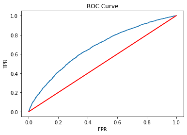

```python
plt.plot(fpr,tpr)
plt.plot([[0,0],[1,1]],color='red')

plt.xlabel('FPR')
plt.ylabel('TPR')
plt.title('ROC Curve')

plt.show()
```

```python
roc_auc_score(y_train,prob)  # area under the curve
```

```
0.6677422797380335
```

```python
#Recursive Feature Elimination
lr = LogisticRegression()
rfe = RFE(estimator=lr) # , scoring='r2')
rfe_model = rfe.fit(X,y)
rfe_model.ranking_
rank= pd.DataFrame()
rank['Feature']=X.columns
rank['Feature_Rank']=rfe_model.ranking_
fea_r=rank[rank['Feature_Rank']==1]
fea_r
```

|  | Feature | Feature_Rank |
| --- | --- | --- |
| 0 | destination | 1 |
| 2 | weather | 1 |
| 4 | time | 1 |
| 5 | coupon | 1 |
| 6 | expiration | 1 |
| 7 | gender | 1 |
| 14 | CoffeeHouse | 1 |
| 18 | has_children | 1 |
| 19 | toCoupon_GEQ15min | 1 |
| 20 | toCoupon_GEQ25min | 1 |
| 21 | direction_same | 1 |

###### LogisticRegression Model For Train Data

```python
fea_r.count()
```

```
Feature         11
Feature_Rank    11
dtype: int64
```

```python
X_new= SelectKBest(chi2, k=11).fit_transform(X, y)
X_new.shape
```

```
(12684, 11)
```

###### TRAIN,TEST SPLIT

```python
X_train, X_test, y_train, y_test = train_test_split(X_new, y, test_size = 0.2, random_state = 1)
```

sc = StandardScaler() X_train = sc.fit_transform(X_train) X_test = sc.transform(X_test)

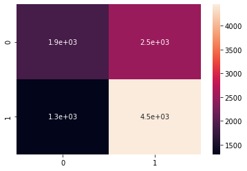

```
              precision    recall  f1-score   support

           0       0.59      0.43      0.50      4396
           1       0.64      0.77      0.70      5751

    accuracy                           0.62     10147
   macro avg       0.62      0.60      0.60     10147
weighted avg       0.62      0.62      0.61     10147

62.42239085443973
```

```python
classifier = LogisticRegression(random_state = 1)
classifier.fit(X_train, y_train)

# Predicting the Test set results
y_pred_train = classifier.predict(X_train)

# Making the Confusion Matrix
from sklearn.metrics import confusion_matrix, accuracy_score,roc_curve,roc_auc_score,precision_score,recall_score
cm = confusion_matrix(y_train, y_pred_train)

y_act = y_train
sns.heatmap(confusion_matrix(y_act,y_pred_train),annot=True)
plt.show()

from sklearn.metrics import classification_report
print(classification_report(y_train,y_pred_train))

lr_train_acc_score = accuracy_score(y_train, y_pred_train)
print(lr_train_acc_score*100)
```

```python
cnf_mat = confusion_matrix(y_act,y_pred_train)
tn = cnf_mat[0,0]
tp = cnf_mat[1,1]
fp = cnf_mat[0,1]
fn = cnf_mat[1,0]
tn,tp,fp,fn
```

```
(1883, 4451, 2513, 1300)
```

```python
# True Negative from confusion matrix
TN = cm[0][0]
# True Positive from confusion matrix
TP = cm[1][1]
# False Positive from confusion matrix
FP = cm[0][1]
# False Negative from confusion matrix
FN = cm[1][0]

# add all the values of a confusion matrix
total = TN + TP + FP + FN

# find the percentage of correctly classified observations
# round the result upto 2 decimal points
correct_classified_percentage = ((TN+TP)/total)*100
print("Percentage of correctly classified observations: ", round(correct_classified_percentage, 2))

# find the percentage of  misclassified observations
# round the result upto 2 decimal points
misclassified_percentage = ((FP+FN)/total)*100
print("Percentage of misclassified observations: ", round(misclassified_percentage, 2))

# find the specificity
# round the result upto 4 decimal points
specificity = TN/(TN+FP)
print("\nSpecificity: ", round(specificity, 4))

# find the sensitivity
# round the result upto 4 decimal points
sensitivity = TP/(TP+FN)
print("Sensitivity: ", round(sensitivity, 4))
```

```
Percentage of correctly classified observations:  62.42
Percentage of misclassified observations:  37.58

Specificity:  0.4283
Sensitivity:  0.774
```

```python
lr_train_acc = (tn+tp)/(tn+tp+fn+fp)
lr_train_acc
```

```
0.6242239085443974
```

```python
print("Accuracy:",metrics.accuracy_score(y_train, y_pred_train))
print("Precision:",metrics.precision_score(y_train, y_pred_train))
print("Recall:",metrics.recall_score(y_train, y_pred_train))
```

```
Accuracy: 0.6242239085443974
Precision: 0.6391441700172314
Recall: 0.7739523561119805
```

```python
prob = classifier.predict_proba(X_train)
prob = prob[:,1]
```

```python
fpr,tpr,thres = roc_curve(y_train,prob)
df_prob = pd.DataFrame({'TPR':tpr,'FPR':fpr,'Threshold':thres})
df_prob
```

|  | TPR | FPR | Threshold |
| --- | --- | --- | --- |
| 0 | 0.000000 | 0.000000 | 1.888822 |
| 1 | 0.000174 | 0.000000 | 0.888822 |
| 2 | 0.000174 | 0.000455 | 0.881987 |
| 3 | 0.001217 | 0.000455 | 0.872689 |
| 4 | 0.001217 | 0.000682 | 0.871418 |
| ... | ... | ... | ... |
| 5264 | 0.999826 | 0.996588 | 0.226907 |
| 5265 | 1.000000 | 0.996588 | 0.226806 |
| 5266 | 1.000000 | 0.998863 | 0.205808 |
| 5267 | 1.000000 | 0.999545 | 0.195082 |
| 5268 | 1.000000 | 1.000000 | 0.179159 |

5269 rows × 3 columns

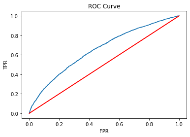

```python
plt.plot(fpr,tpr)
plt.plot([[0,0],[1,1]],color='red')

plt.xlabel('FPR')
plt.ylabel('TPR')
plt.title('ROC Curve')

plt.show()
```

```python
roc_auc_score(y_train,prob)  # area under the curve
```

```
0.6554609761264766
```

###### TEST DATA

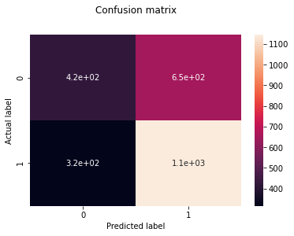

```
              precision    recall  f1-score   support

           0       0.57      0.39      0.47      1078
           1       0.64      0.78      0.70      1459

    accuracy                           0.62      2537
   macro avg       0.61      0.59      0.59      2537
weighted avg       0.61      0.62      0.60      2537

61.84469846275128
```

```python
# Fitting Logistic Regression to the Testing Data set
from sklearn.linear_model import LogisticRegression
classifier = LogisticRegression(random_state = 0)
classifier.fit(X_test, y_test)

# Predicting the Test set results
y_pred = classifier.predict(X_test)

# Making the Confusion Matrix
from sklearn.metrics import confusion_matrix, accuracy_score
cm = confusion_matrix(y_test, y_pred)

y_act = y_test
sns.heatmap(confusion_matrix(y_act,y_pred),annot=True)
plt.title('Confusion matrix', y=1.1)
plt.ylabel('Actual label')
plt.xlabel('Predicted label')
plt.show()

from sklearn.metrics import classification_report
print(classification_report(y_test,y_pred))

lr_test_acc_score = accuracy_score(y_test, y_pred)
print(lr_test_acc_score*100)
```

```python
cnf_mat = confusion_matrix(y_act,y_pred)
tn = cnf_mat[0,0]
tp = cnf_mat[1,1]
fp = cnf_mat[0,1]
fn = cnf_mat[1,0]
tn,tp,fp,fn
```

```
(425, 1144, 653, 315)
```

```python
# True Negative from confusion matrix
TN = cm[0][0]
# True Positive from confusion matrix
TP = cm[1][1]
# False Positive from confusion matrix
FP = cm[0][1]
# False Negative from confusion matrix
FN = cm[1][0]

# add all the values of a confusion matrix
total = TN + TP + FP + FN

# find the percentage of correctly classified observations
# round the result upto 2 decimal points
correct_classified_percentage = ((TN+TP)/total)*100
print("Percentage of correctly classified observations: ", round(correct_classified_percentage, 2))

# find the percentage of  misclassified observations
# round the result upto 2 decimal points
misclassified_percentage = ((FP+FN)/total)*100
print("Percentage of misclassified observations: ", round(misclassified_percentage, 2))

# find the specificity
# round the result upto 4 decimal points
specificity = TN/(TN+FP)
print("\nSpecificity: ", round(specificity, 4))

# find the sensitivity
# round the result upto 4 decimal points
sensitivity = TP/(TP+FN)
print("Sensitivity: ", round(sensitivity, 4))
```

```
Percentage of correctly classified observations:  61.84
Percentage of misclassified observations:  38.16

Specificity:  0.3942
Sensitivity:  0.7841
```

```python
lr_test_acc = (tn+tp)/(tn+tp+fn+fp)
lr_test_acc
```

```
0.6184469846275128
```

```python
prob = classifier.predict_proba(X_test)
prob = prob[:,1]
```

```python
fpr,tpr,thres = roc_curve(y_test,prob)
df_prob = pd.DataFrame({'TPR':tpr,'FPR':fpr,'Threshold':thres})
df_prob
```

|  | TPR | FPR | Threshold |
| --- | --- | --- | --- |
| 0 | 0.000000 | 0.000000 | 1.891015 |
| 1 | 0.000685 | 0.000000 | 0.891015 |
| 2 | 0.019191 | 0.000000 | 0.830514 |
| 3 | 0.019191 | 0.000928 | 0.829368 |
| 4 | 0.021933 | 0.000928 | 0.824551 |
| ... | ... | ... | ... |
| 1271 | 0.998629 | 0.994434 | 0.263797 |
| 1272 | 0.998629 | 0.996289 | 0.263011 |
| 1273 | 0.999315 | 0.996289 | 0.262672 |
| 1274 | 0.999315 | 1.000000 | 0.241122 |
| 1275 | 1.000000 | 1.000000 | 0.234467 |

1276 rows × 3 columns

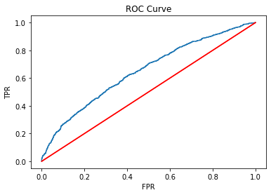

```python
plt.plot(fpr,tpr)
plt.plot([[0,0],[1,1]],color='red')
plt.xlabel('FPR')
plt.ylabel('TPR')
plt.title('ROC Curve')
plt.show()
```

```python
roc_auc_score(y_test,prob)  # area under the curve
```

```
0.64955156465976
```

###### Naive Bayes

###### Train Data

```python
# instantiate the 'GaussianNB'
gnb = GaussianNB()

# fit the model using fit() on train data
gnb_model_train = gnb.fit(X_train, y_train)

# predict the attrition for test set
y_pred_train = gnb_model_train.predict(X_train)

# print the classification report
print(classification_report(y_train, y_pred_train))
```

```
              precision    recall  f1-score   support

           0       0.58      0.37      0.45      4396
           1       0.62      0.80      0.70      5751

    accuracy                           0.61     10147
   macro avg       0.60      0.58      0.58     10147
weighted avg       0.61      0.61      0.59     10147
```

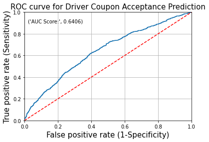

```python
# plot the ROC curve
plot_roc(gnb_model_train)
```

```python
roc_auc_score(y_train, y_pred_train)
```

```
0.5842162750822778
```

```python
# define a to plot a confusion matrix for the model
from matplotlib.colors import ListedColormap
def plot_confusion_matrix(model):

    # predict the target values using X_train
    y_pred_train = model.predict(X_train)

    # create a confusion matrix
    # pass the actual and predicted target values to the confusion_matrix()
    cm = confusion_matrix(y_train, y_pred_train)

    # label the confusion matrix
    # pass the matrix as 'data'
    # pass the required column names to the parameter, 'columns'
    # pass the required row names to the parameter, 'index'
    conf_matrix = pd.DataFrame(data = cm,columns = ['Predicted:0','Predicted:1'],
                               index = ['Actual:0','Actual:1'])

    # plot a heatmap to visualize the confusion matrix
    # 'annot' prints the value of each grid
    # 'fmt = d' returns the integer value in each grid
    # 'cmap' assigns color to each grid
    # as we do not require different colors for each grid in the heatmap,
    # use 'ListedColormap' to assign the specified color to the grid
    # 'cbar = False' will not return the color bar to the right side of the heatmap
    # 'linewidths' assigns the width to the line that divides each grid
    # 'annot_kws = {'size':25})' assigns the font size of the annotated text
    sns.heatmap(conf_matrix, annot = True, fmt = 'd', cbar = False,cmap = ListedColormap(['lightskyblue']),
                linewidths = 0.1, annot_kws = {'size':15})

    # set the font size of x-axis ticks using 'fontsize'
    plt.xticks(fontsize = 10)

    # set the font size of y-axis ticks using 'fontsize'
    plt.yticks(fontsize = 10)

    # display the plot
    plt.show()#### Define a function to plot the confusion matrix.
```

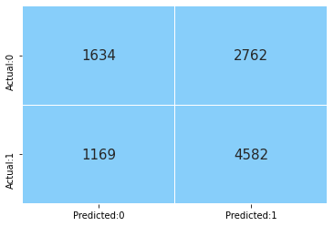

```python
# call the function to plot the confusion matrix
# pass the knn model to the function
plot_confusion_matrix(gnb_model_train)
```

```python
cnf_mat = confusion_matrix(y_train,y_pred_train)
tn = cnf_mat[0,0]
tp = cnf_mat[1,1]
fp = cnf_mat[0,1]
fn = cnf_mat[1,0]
tn,tp,fp,fn
```

```
(1634, 4582, 2762, 1169)
```

```python
# True Negative from confusion matrix
TN = cm[0][0]
# True Positive from confusion matrix
TP = cm[1][1]
# False Positive from confusion matrix
FP = cm[0][1]
# False Negative from confusion matrix
FN = cm[1][0]

# add all the values of a confusion matrix
total = TN + TP + FP + FN

# find the percentage of correctly classified observations
# round the result upto 2 decimal points
correct_classified_percentage = ((TN+TP)/total)*100
print("Percentage of correctly classified observations: ", round(correct_classified_percentage, 2))

# find the percentage of  misclassified observations
# round the result upto 2 decimal points
misclassified_percentage = ((FP+FN)/total)*100
print("Percentage of misclassified observations: ", round(misclassified_percentage, 2))

# find the specificity
# round the result upto 4 decimal points
specificity = TN/(TN+FP)
print("\nSpecificity: ", round(specificity, 4))

# find the sensitivity
# round the result upto 4 decimal points
sensitivity = TP/(TP+FN)
print("Sensitivity: ", round(sensitivity, 4))
```

```
Percentage of correctly classified observations:  61.84
Percentage of misclassified observations:  38.16

Specificity:  0.3942
Sensitivity:  0.7841
```

```python
nb_train_acc = (tn+tp)/(tn+tp+fn+fp)
nb_train_acc
```

```
0.6125948556223514
```

```python
print("Accuracy:",metrics.accuracy_score(y_train, y_pred_train))
print("Precision:",metrics.precision_score(y_train, y_pred_train))
print("Recall:",metrics.recall_score(y_train, y_pred_train))
```

```
Accuracy: 0.6125948556223514
Precision: 0.6239106753812637
Recall: 0.7967310033037732
```